# PA1_template.Rmd

Marcelo Tibau

28 de julho de 2016

# Reproducible Research: Peer Assessment 1

## Loading and preprocessing the data

Codes to load and preprocess the data:

```r
directory <- ("activity")
file <- ("activity.csv")
activity <- read.csv(file.path(directory, file))
activity_na_omit <- na.omit(activity)
total_ac_na_omit <- aggregate(steps ~ date, activity_na_omit, sum)
```

## What is mean total number of steps taken per day?

Code to make a histogram of the total number of steps taken each day:

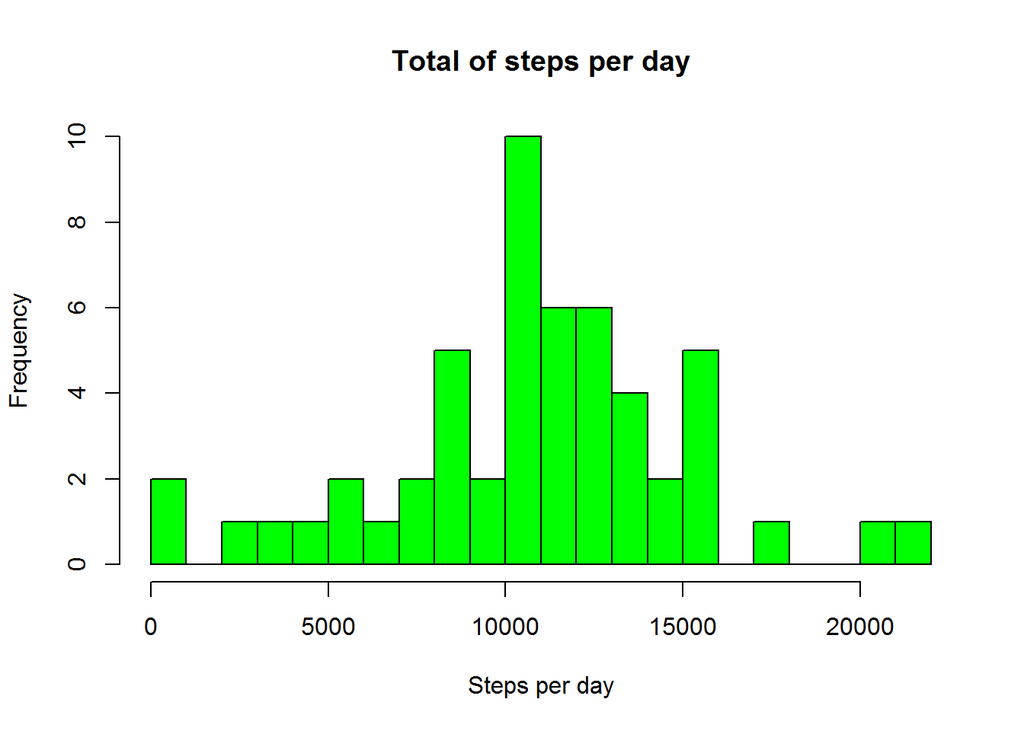

```r
hist(
        total_ac_na_omit$steps,
        main = "Total of steps per day",
        xlab="Steps per day",
        ylab="Frequency",
        col = "green",
        breaks = 20
        )
```

Codes to calculate the mean and median total number of steps taken per day:

```r
steps_mean <- mean(total_ac_na_omit$steps)
steps_median <- median(total_ac_na_omit$steps)
print(steps_mean)
```

```
## [1] 10766.19
```

```r
print(steps_median)
```

```
## [1] 10765
```

## What is the average daily activity pattern?

Code to preprocess the data:

```r
total_ac_average <- aggregate(steps ~ interval, activity_na_omit, mean)
```

Code to create a time series plot:

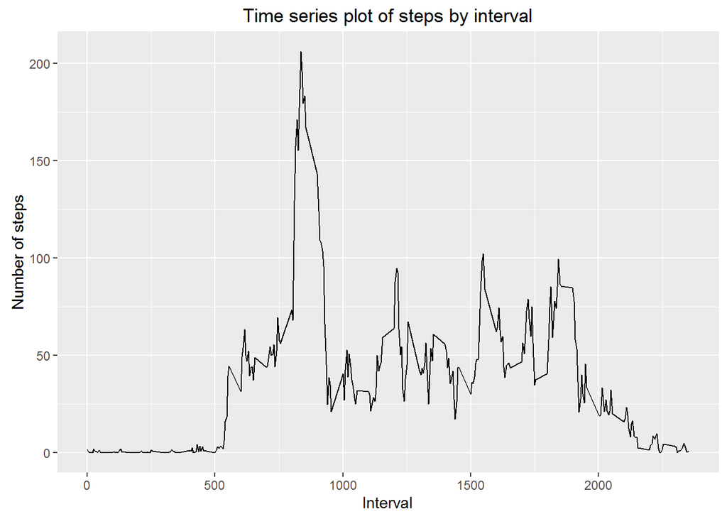

```r
library(ggplot2)
par(mar = c(1.5, 1.5, 1, 1))
ggplot(total_ac_average, aes(interval, steps)) +
        geom_line() +
        ggtitle("Time series plot of steps by interval") +
        xlab("Interval") +
        ylab("Number of steps")
```

Code to calculate the maximum number of steps:

```r
max_number_steps <- which.max(total_ac_average$steps)
print(total_ac_average[max_number_steps,])
```

```
##     interval    steps
## 104      835 206.1698
```

## Imputing missing values.

Code to calculate the total number of missing values in the dataset:

```r
number_na <- sum(is.na(activity$steps))
print(number_na)
```

```
## [1] 2304
```

Code to fill in all of the missing values in the dataset:

```r
fill_na <- function(steps, interval) {
        fill_ac <- NA
        if (!is.na(steps))
                fill_ac <- c(steps)
        else
                fill_ac <- (total_ac_average[total_ac_average$interval==interval, "steps"])
        return(fill_ac)
}
```

Codes to create a new dataset with the missing data filled in:

```r
new_activity <- activity
new_activity$steps <- mapply(fill_na, new_activity$steps, new_activity$interval)
```

Codes to make a histogram of the total number of steps taken each day and to calculate the mean and median total number of steps taken per day:

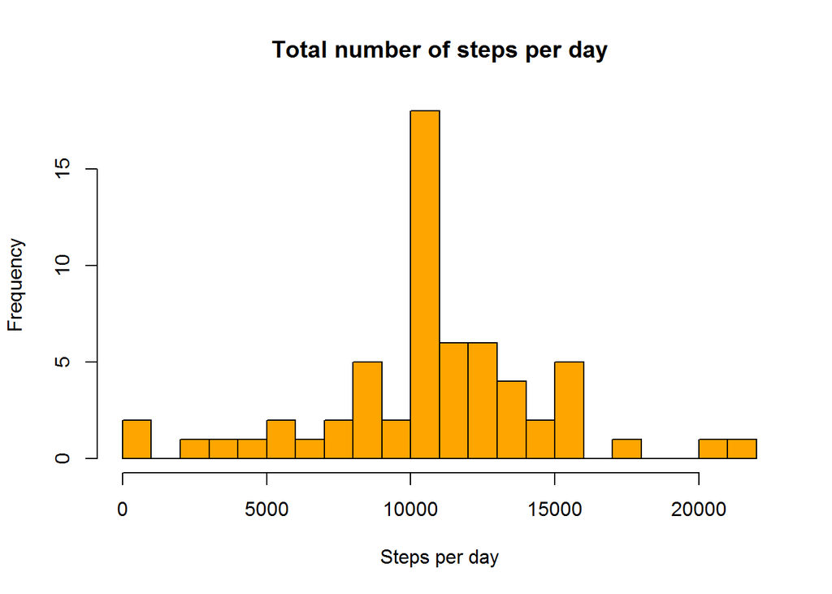

```r
total_ac_steps <- aggregate(steps ~ date, new_activity, sum)
hist(
        total_ac_steps$steps,
        main = "Total number of steps per day",
        xlab="Steps per day",
        ylab="Frequency",
        col = "orange",
        breaks = 20
)
```

```r
total_ac_steps_mean <- mean(total_ac_steps$steps)
total_ac_steps_median <- median(total_ac_steps$steps)
print(total_ac_steps_mean)
```

```
## [1] 10766.19
```

```r
print(total_ac_steps_median)
```

```
## [1] 10766.19
```

### Do these values differ from the estimates from the first part of the assignment?

They do differ, although slightly. The mean concerning the total number of steps taken per day - considering the missing values - is 10766.19, while the mean with all the NA filled in by the mean is also 10766.19. But the median is a bit different. While the median - considering the missing values - is 10765, the median with the NA filled in by the mean is 10766.19.

### What is the impact of imputing missing data on the estimates of the total daily number of steps?

If we consider the mean, there was no impact at all, since I opted to use the mean itself to fill in all the NA. Although there was a difference at the medians, it was by 1.19. It seems to have no great impact.

## Are there differences in activity patterns between weekdays and weekends?

Codes to create the new factor variable in the dataset with the levels “weekday” and “weekend”:

```r
week_activity <- new_activity

week_activity$date <- as.Date(strptime(week_activity$date, format="%Y-%m-%d"))

week_activity$day <-  factor(ifelse(as.POSIXlt(week_activity$date)$wday %in% c(0,6), 'weekend', 'weekday'))
```

Code to calculate the averaged number of steps taken by “weekday”" or “weekend”:

```r
averaged_week_activity <- aggregate(steps ~ interval + day, data=week_activity, mean)
```

Code to plot a time series of the 5-minute interval (x-axis) and the average number of steps taken, averaged across all weekday days or weekend days (y-axis):

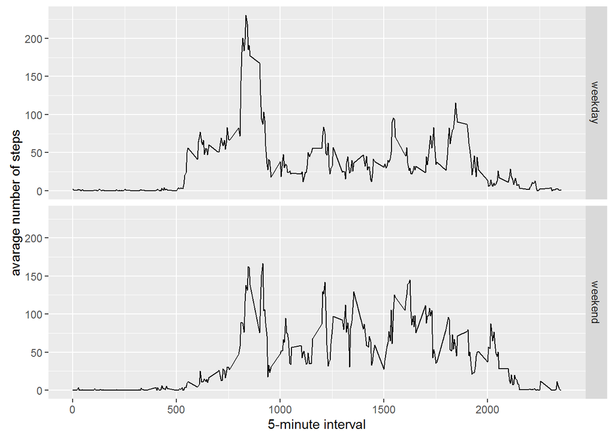

```r
library(ggplot2)
ggplot(averaged_week_activity, aes(interval, steps)) +
        geom_line() +
        facet_grid(day ~ .) +
        xlab("5-minute interval") +
        ylab("avarage number of steps")
```